# Data wrangling and viualization

# Reshaping with gather and spread (Pivot_wider and longer now)

Rules of data: 1. Each variable has its own column 2. Each observation has its own row 3. Each value must have its own cell 4. Each type of observational unit forms a table

In our surveys data each row is one observational unit. Sometimes we want to compare various columns (variable) for each observational unit

Spreading- spreads the data so that rows becomes columns gather- does the reverse

spread() takes three principal arguments: 1. the data 2. the key column variable whose values will become new column names. 3. the value column variable whose values will fill the new column variables.

# Lets find mean wt of each genus in each plot over the entire survey period per plot id

```r
surveys_gw<- surveys %>%
  filter(!is.na(weight)) %>%
  group_by(plot_id,genus) %>%
  summarize(mean_wt= mean(weight))
head(surveys_gw)
```

| plot_id | genus | mean_wt |
| --- | --- | --- |
| 1 | Baiomys | 7.00000 |
| 1 | Chaetodipus | 22.19939 |
| 1 | Dipodomys | 60.23214 |
| 1 | Neotoma | 156.22222 |
| 1 | Onychomys | 27.67550 |
| 1 | Perognathus | 9.62500 |

# Now take genus and make them columns

```r
surveys_Spread<- surveys_gw %>%
  spread(key=genus, value = mean_wt)
head(surveys_Spread)
```

| plot_id | Baiomys | Chaetodipus | Dipodomys | Neotoma | Onychomys | Perognathus | Peromyscus | Reithrodontomys | Sigmodon | Spermophilus |
| --- | --- | --- | --- | --- | --- | --- | --- | --- | --- | --- |
| 1 | 7.000000 | 22.19939 | 60.23214 | 156.2222 | 27.67550 | 9.625000 | 22.22222 | 11.37500 | NA | NA |
| 2 | 6.000000 | 25.11014 | 55.68259 | 169.1436 | 26.87302 | 6.947368 | 22.26966 | 10.68056 | 70.85714 | NA |
| 3 | 8.611111 | 24.63636 | 52.04688 | 158.2414 | 26.03241 | 7.507812 | 21.37037 | 10.51659 | 65.61404 | NA |
| 4 | NA | 23.02381 | 57.52454 | 164.1667 | 28.09375 | 7.824427 | 22.60000 | 10.26316 | 82.00000 | NA |
| 5 | 7.750000 | 17.98276 | 51.11356 | 190.0370 | 27.01695 | 8.658537 | 21.23171 | 11.15455 | 82.66667 | NA |
| 6 | NA | 24.86009 | 58.60531 | 179.9333 | 25.89947 | 7.809524 | 21.84043 | 10.67045 | 68.77778 | NA |

# Lets fill the missing values with 0

```r
surveys_gw %>%
  spread(key=genus, value=mean_wt, fill = 0) %>%
  head()
```

| plot_id | Baiomys | Chaetodipus | Dipodomys | Neotoma | Onychomys | Perognathus | Peromyscus | Reithrodontomys | Sigmodon | Spermophilus |
| --- | --- | --- | --- | --- | --- | --- | --- | --- | --- | --- |
| 1 | 7.000000 | 22.19939 | 60.23214 | 156.2222 | 27.67550 | 9.625000 | 22.22222 | 11.37500 | 0.00000 | 0 |
| 2 | 6.000000 | 25.11014 | 55.68259 | 169.1436 | 26.87302 | 6.947368 | 22.26966 | 10.68056 | 70.85714 | 0 |
| 3 | 8.611111 | 24.63636 | 52.04688 | 158.2414 | 26.03241 | 7.507812 | 21.37037 | 10.51659 | 65.61404 | 0 |
| 4 | 0.000000 | 23.02381 | 57.52454 | 164.1667 | 28.09375 | 7.824427 | 22.60000 | 10.26316 | 82.00000 | 0 |
| 5 | 7.750000 | 17.98276 | 51.11356 | 190.0370 | 27.01695 | 8.658537 | 21.23171 | 11.15455 | 82.66667 | 0 |
| 6 | 0.000000 | 24.86009 | 58.60531 | 179.9333 | 25.89947 | 7.809524 | 21.84043 | 10.67045 | 68.77778 | 0 |

```r
NA
```

# Gather is opposite of spread

1. the data
2. the key column variable we wish to create from column names.
3. the values column variable we wish to create and fill with values associated with the key.
4. the names of the columns we use to fill the key variable (or to drop).

[output not shown]

# We can only select few columns to become rows

```r
surveys_spread2 %>%
  gather(key = "genus", value = "mean_wt", Baiomys:Spermophilus) %>%
  head()
```

| plot_id | genus | mean_wt |
| --- | --- | --- |
| 1 | Baiomys | 7.000000 |
| 2 | Baiomys | 6.000000 |
| 3 | Baiomys | 8.611111 |
| 4 | Baiomys | 0.000000 |
| 5 | Baiomys | 7.750000 |
| 6 | Baiomys | 0.000000 |

# Challenge # 15 mins

1. Spread the surveys data frame with year as columns, plot_id as rows, and the number of genera per plot as the values. You will need to summarize before reshaping, and use the function n_distinct() to get the number of unique genera within a particular chunk of data. It’s a powerful function! See ?n_distinct for more.
2. Now take that data frame and gather() it again, so each row is a unique plot_id by year combination.
3. The surveys data set has two measurement columns: hindfoot_length and weight. This makes it difficult to do things like look at the relationship between mean values of each measurement per year in different plot types. Let’s walk through a common solution for this type of problem. First, use gather() to create a dataset where we have a key column called measurement and a value column that takes on the value of either hindfoot_length or weight. Hint: You’ll need to specify which columns are being gathered.
4. With this new data set, calculate the average of each measurement in each year for each different plot_type. Then spread() them into a data set with a column for hindfoot_length and weight. Hint: You only need to specify the key and value columns for spread()

# Visualizing data

Objectives 1. Produce scatter plots, boxplots, and time series plots using ggplot. 2. Set universal plot settings. 3. Describe what faceting is and apply faceting in ggplot. 4. Modify the aesthetics of an existing ggplot plot (including axis labels and color). 5. Build complex and customized plots from data in a data frame.

# Plotting with ggplot

1. Helps creates publication quality graphs
2. more intuitive
3. step by step addition of layers
4. likes the data in long format

ggplot(data = , mapping = aes()) + ()

# Scatterplot

[figure not shown]

# ‘+’ allows you to assign a name to plot and customize it with as many layers

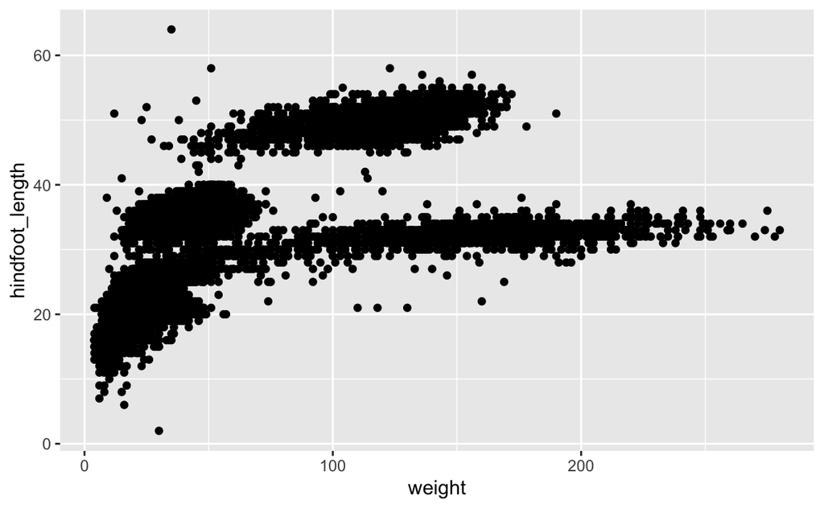

```r
surveys_plot <- ggplot(data = surveys_complete,
                       mapping = aes(x = weight, y = hindfoot_length))
# Draw the plot
surveys_plot +
    geom_point()
```

# Custom setting

Anything you add on ggplot function The + sign used to add layers must be placed at the end of each line containing a layer.

# Lets modify the plots

Reduce opacity

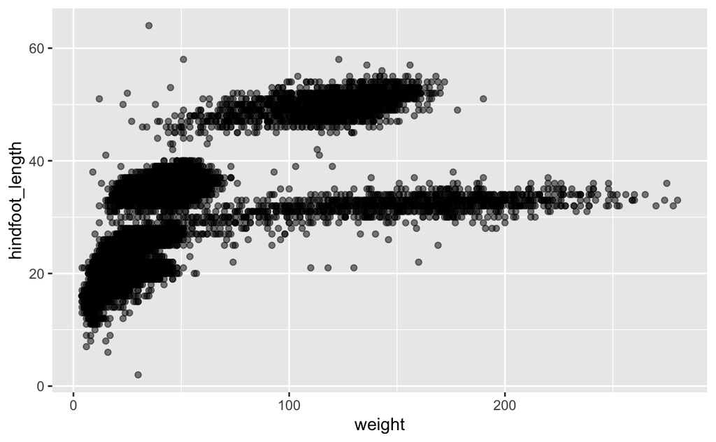

```r
surveys_complete<-read_csv("data/surveys_complete.csv")
ggplot(data = surveys_complete, aes(x = weight, y = hindfoot_length) ) +
  geom_point(alpha=0.5)
```

# Lets change color of points

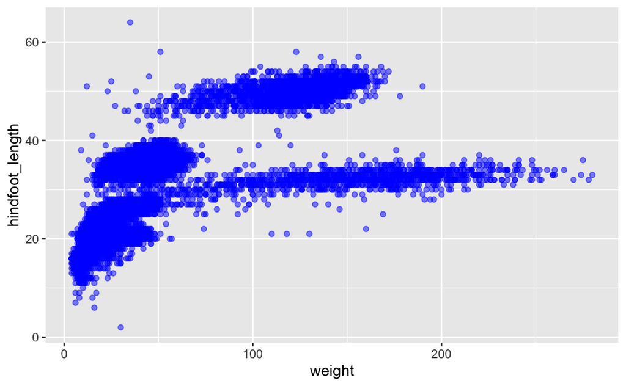

```r
ggplot(data = surveys_complete, aes(x = weight, y = hindfoot_length) ) +
  geom_point(alpha=0.5,color='blue')
```

# Lets plot so that each species has a diff color

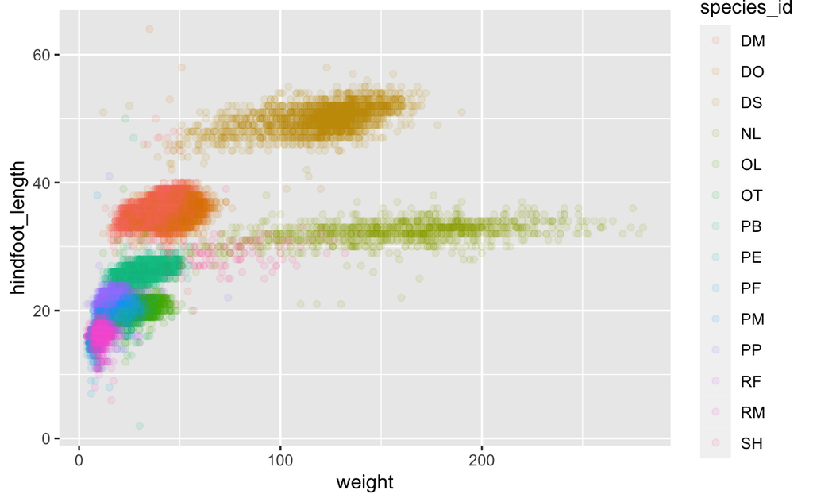

```r
ggplot(data = surveys_complete, aes(x = weight, y = hindfoot_length) ) +
  geom_point(aes(color=species_id), alpha=0.1)
```

# Challenge

Use what you just learned to create a scatter plot of weight over species_id with the plot types showing in different colors. Is this a good way to show this type of data?

# Boxplot

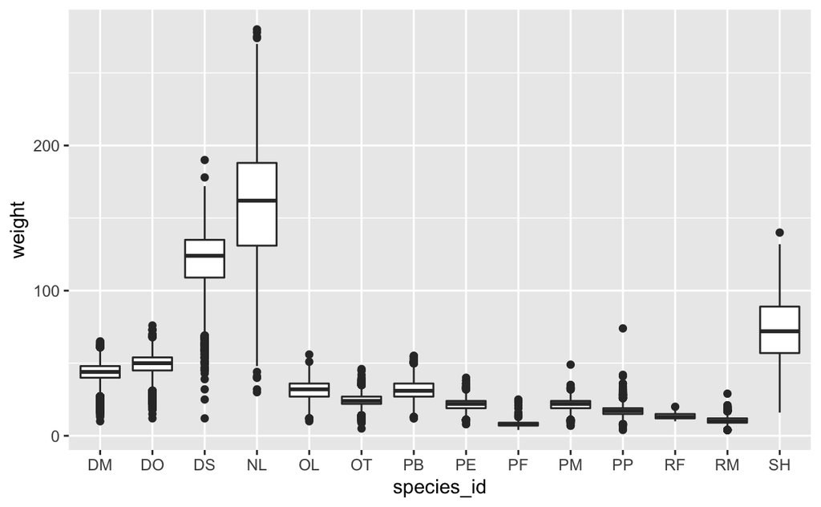

```r
ggplot(data = surveys_complete, mapping = aes(x = species_id, y = weight)) +
    geom_boxplot()
```

# Lets plot data over box plot

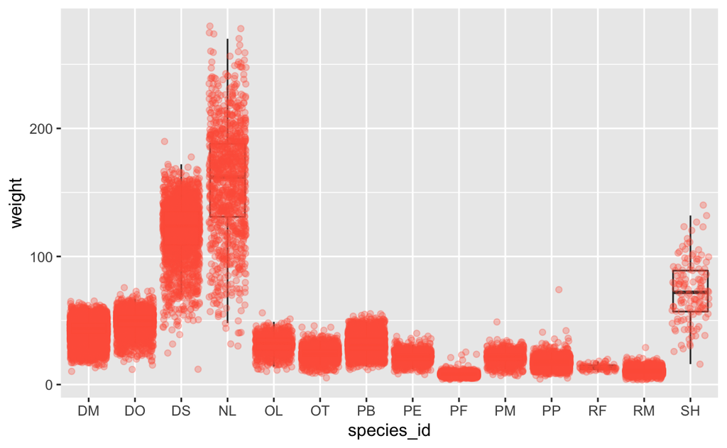

```r
ggplot(data = surveys_complete, mapping = aes(x = species_id, y = weight)) +
    geom_boxplot(alpha = 0) +
    geom_jitter(alpha = 0.3, color = "tomato")
```

# Challege

Boxplots are useful summaries, but hide the shape of the distribution. For example, if there is a bimodal distribution, it would not be observed with a boxplot. An alternative to the boxplot is the violin plot (sometimes known as a beanplot), where the shape (of the density of points) is drawn.

1. Replace the box plot with a violin plot; see geom_violin().

In many types of data, it is important to consider the scale of the observations. 2. Represent weight on the log10 scale; see scale_y_log10()

```r
ggplot(data = surveys_complete, mapping = aes(x = species_id, y = weight)) +
    geom_violin(alpha = 0.9) +
  scale_y_log()
    #geom_jitter(alpha = 0.1, color = "tomato")
```

# Plotting time series data

Lets look at counts of every genus every year

```r
yearly_counts <- surveys_complete %>%
  count(year, genus)
```

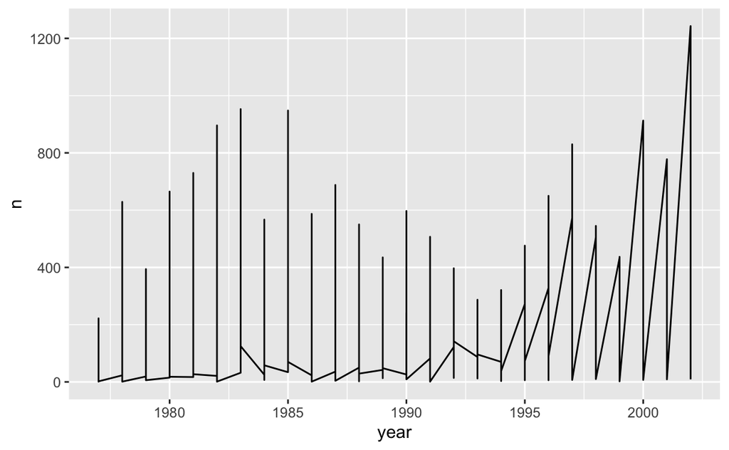

```r
ggplot(data = yearly_counts, aes(x = year, y = n)) +
     geom_line()
```

# Lets have one line for each genus

```r
ggplot(data = yearly_counts, aes(x = year, y = n)) +
     geom_line(aes(color=genus))
```

[output not shown]

# Integrating pipe operator with ggplot

Make life easy

```r
yearly_counts %>%
    ggplot(mapping = aes(x = year, y = n, color = genus)) +
    geom_line()
```

[output not shown]

# Faceting

Create mini plots

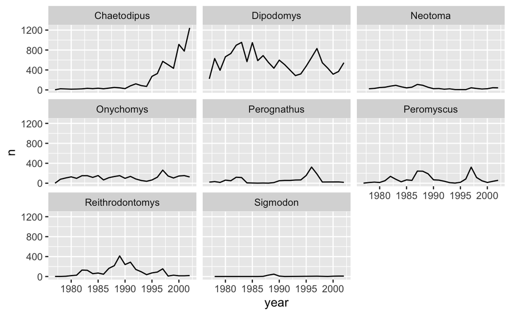

```r
ggplot(data = yearly_counts, aes(x = year, y = n)) +
    geom_line() +
    facet_wrap(facets = vars(genus))
```

# Now color with sex

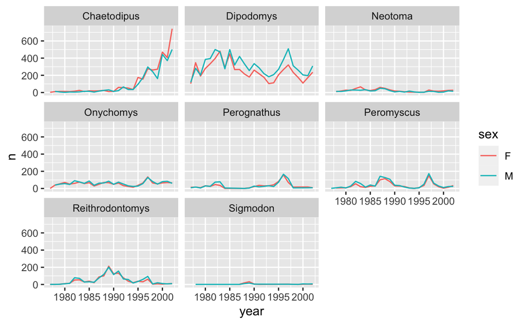

```r
 surveys_complete %>%
  count(year, genus, sex) %>%
ggplot( aes(x = year, y = n,color=sex)) +
    geom_line() +
    facet_wrap(facets = vars(genus))
```

# Use facet_grid for arranging only in rows

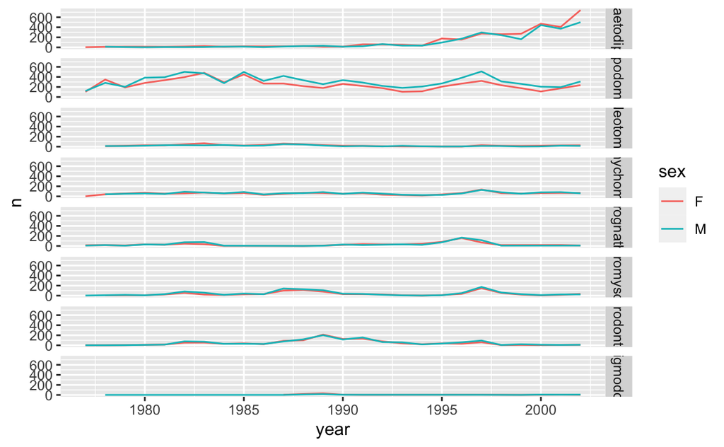

```r
 surveys_complete %>%
  count(year, genus, sex) %>%
ggplot( aes(x = year, y = n,color=sex)) +
    geom_line() +
    facet_grid(facets = vars(genus))
```

# ggplot themes

Publication quality plots

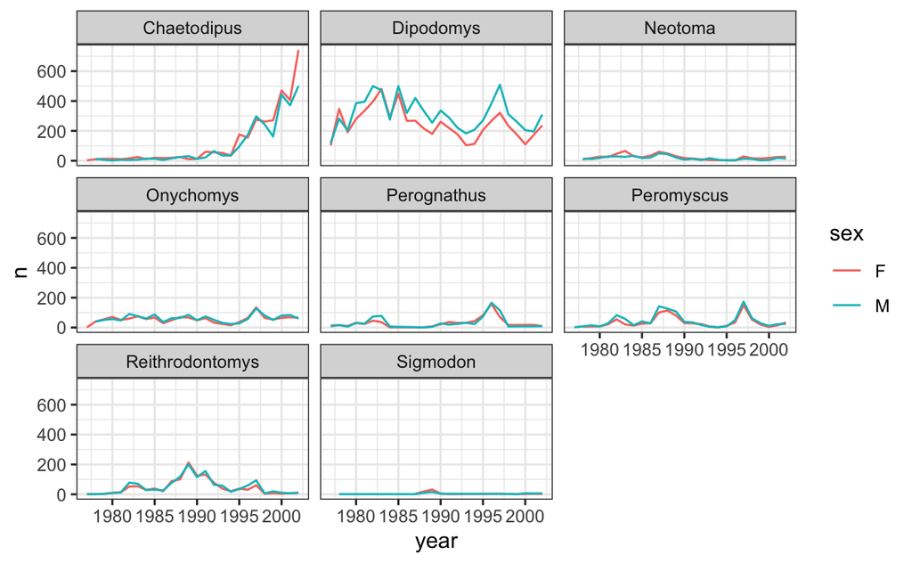

```r
surveys_complete %>%
  count(year, genus, sex) %>%
 ggplot( mapping = aes(x = year, y = n, color = sex)) +
     geom_line() +
     facet_wrap(vars(genus)) +
     theme_bw()
```

# Challenge- 15 mins

Use what you just learned to create a plot that depicts how the average weight of each species changes through the years. Use ggplot cheat sheet and improve your plot, share some ideas with your group https://rstudio.com/wp-content/uploads/2015/03/ggplot2-cheatsheet.pdf

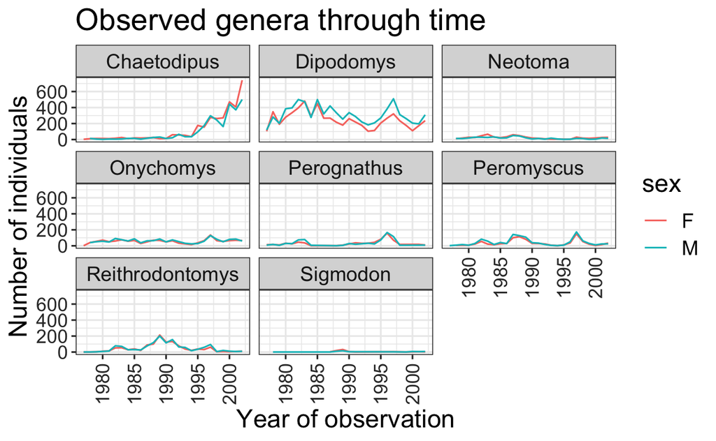

```r
surveys_complete %>%
  count(year, genus, sex) %>%
ggplot(mapping = aes(x = year, y = n, color = sex)) +
    geom_line() +
    facet_wrap(vars(genus)) +
    labs(title = "Observed genera through time",
        x = "Year of observation",
        y = "Number of individuals") +
    theme_bw() +
       theme(axis.text.x = element_text(colour = "grey20", size = 12, angle = 90,hjust = 0.5, vjust = 0.5),axis.text.y = element_text(colour = "grey20", size = 12), text = element_text(size = 16))
```

# Save your themes

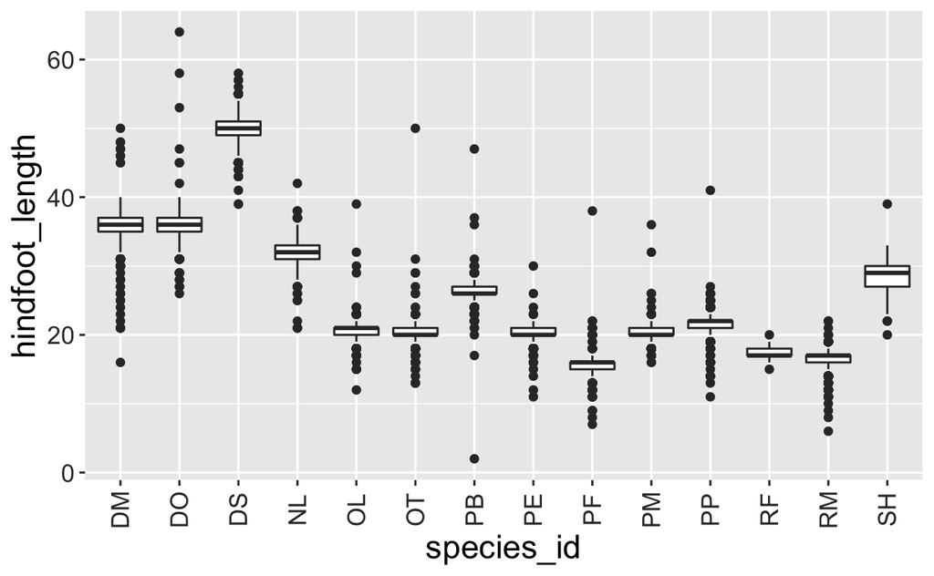

```r
grey_theme <- theme(axis.text.x = element_text(colour="grey20", size = 12,
                                               angle = 90, hjust = 0.5,
                                               vjust = 0.5),
                    axis.text.y = element_text(colour = "grey20", size = 12),
                    text=element_text(size = 16))

ggplot(surveys_complete, aes(x = species_id, y = hindfoot_length)) +
    geom_boxplot() +
    grey_theme
```

# Challenge -15 mins

With all of this information in hand, please take another five minutes to either improve one of the plots generated in this exercise or create a beautiful graph of your own. Use the RStudio ggplot2 cheat sheet for inspiration.

Here are some ideas:

See if you can change the thickness of the lines. Can you find a way to change the name of the legend? What about its labels? Try using a different color palette (see http://www.cookbook-r.com/Graphs/Colors_(ggplot2)/).

# Exporting plots

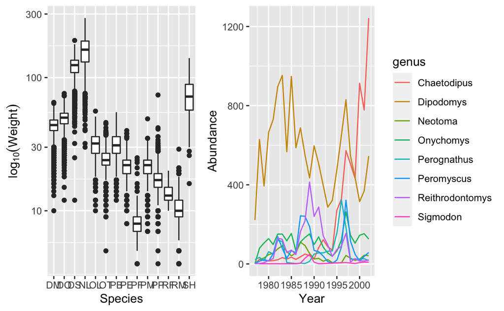

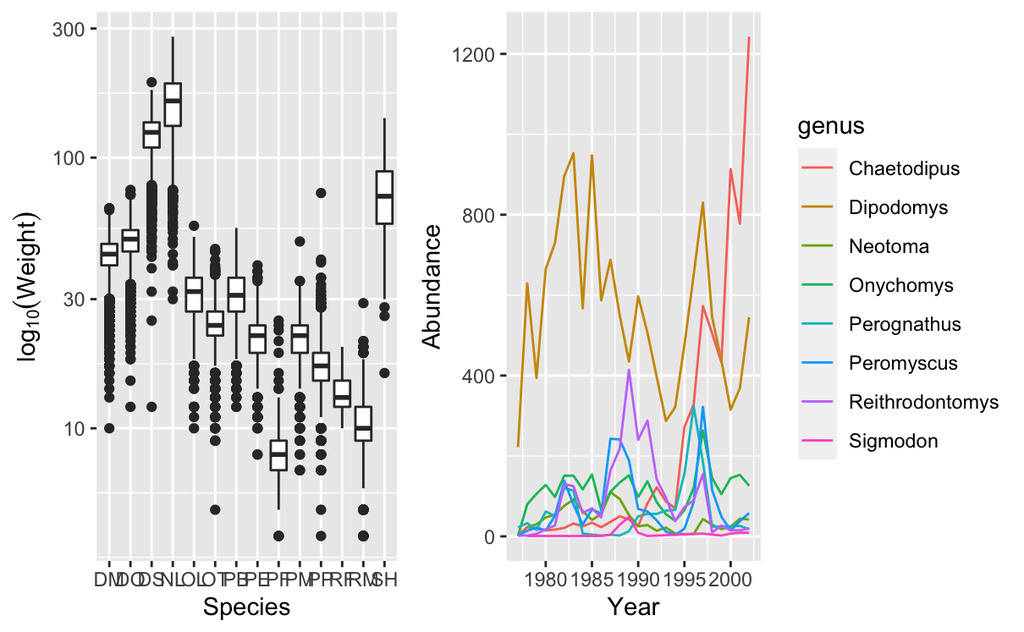

```r
comb_plot<-grid.arrange(spp_weight_boxplot, spp_count_plot, ncol = 2, widths = c(4, 6))
comb_plot<-grid.arrange(spp_weight_boxplot, spp_count_plot, ncol = 2, widths = c(4, 6))

  ggsave("combo_plot.png",comb_plot,dpi=300)
```